# Week Two Unit 2 Part 3

Weijia Chen

23 September 2014

### Normal Distribution

#### Normal Distribution

- Unimodal and symmetric
- Bell curve
- Follows very strict guidelines about how variably the data are distributed around the mean
- Many variables are nearly normal, but none are exactly normal
- $N(\mu, \sigma)$

#### 68-95-99.7% Rule

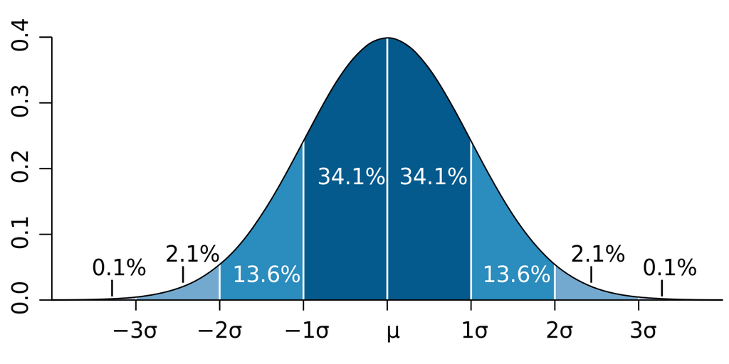

*68% Falls within one standard deviation of the mean $[\mu - \sigma, \mu + \sigma]$*

*95% Falls within two standard deviation of the mean* $[\mu - {2} \sigma, \mu + {2} \sigma]$

#### Standardised Scores ($Z$ score)

1. *Standardised $Z$ score* of an observation is *the number of standard deviation* it falls above or below the mean.
2. $Z = \frac{observation \ - \ mean}{SD}$
3. $Z$ score of mean = 0; $Z = \frac{mean \ - \ mean}{SD} = 0$
4. Unusual observaiton: $\left| Z \right| > 2$
5. Defined for distributions of any shape

#### Probabilities and percentiles

1. When the distribution is normal, $Z$ scores can be used to calculate percentiles
2. *Percentile* is the percentage of observations that *fall below a given data point*
3. Graphically, percentile is the area *below* the probability distribution curve to the *left of that observation*.

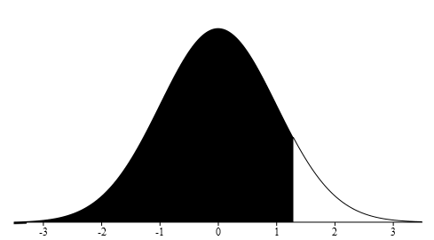

### Evaluating the Normal Distribution

### Working with the Normal Distribution